# Risk Factor Analysis

## Outcome Variable

**Outcome Variable:** sstunted

## Predictor Variables

**Intervention Variable:** tr

**Adjustment Set:**

unadjusted

## Stratifying Variables

The analysis was stratified on these variable(s):

- agecat
- studyid
- country
- intXgagebrth

## Data Summary

| agecat | studyid | country | intXgagebrth | sstunted | n_cell | n |
| --- | --- | --- | --- | --- | --- | --- |
| Birth | iLiNS_DYADM_LNS | MALAWI | Full or late term_Birth | 0 | 0 | 1 |
| Birth | iLiNS_DYADM_LNS | MALAWI | Full or late term_Birth | 1 | 1 | 1 |
| Birth | ki1000304b-SAS-CompFeed | INDIA | Preterm_Birth | 0 | 125 | 135 |
| Birth | ki1000304b-SAS-CompFeed | INDIA | Preterm_Birth | 1 | 10 | 135 |
| Birth | ki1000304b-SAS-CompFeed | INDIA | Early term_Birth | 0 | 8 | 9 |
| Birth | ki1000304b-SAS-CompFeed | INDIA | Early term_Birth | 1 | 1 | 9 |
| Birth | ki1119695-PROBIT | BELARUS | Full or late term_Birth | 0 | 7095 | 7095 |
| Birth | ki1119695-PROBIT | BELARUS | Full or late term_Birth | 1 | 0 | 7095 |
| Birth | ki1119695-PROBIT | BELARUS | Preterm_Birth | 0 | 471 | 472 |
| Birth | ki1119695-PROBIT | BELARUS | Preterm_Birth | 1 | 1 | 472 |
| Birth | ki1119695-PROBIT | BELARUS | Early term_Birth | 0 | 6313 | 6317 |
| Birth | ki1119695-PROBIT | BELARUS | Early term_Birth | 1 | 4 | 6317 |
| Birth | ki1135781-COHORTS | GUATEMALA | Full or late term_Birth | 0 | 338 | 341 |
| Birth | ki1135781-COHORTS | GUATEMALA | Full or late term_Birth | 1 | 3 | 341 |
| Birth | ki1135781-COHORTS | GUATEMALA | Preterm_Birth | 0 | 91 | 95 |
| Birth | ki1135781-COHORTS | GUATEMALA | Preterm_Birth | 1 | 4 | 95 |
| Birth | ki1135781-COHORTS | GUATEMALA | Early term_Birth | 0 | 179 | 181 |
| Birth | ki1135781-COHORTS | GUATEMALA | Early term_Birth | 1 | 2 | 181 |
| Birth | ki1148112-iLiNS-DYAD-M | MALAWI | Full or late term_Birth | 0 | 0 | 1 |
| Birth | ki1148112-iLiNS-DYAD-M | MALAWI | Full or late term_Birth | 1 | 1 | 1 |
| Birth | kiGH5241-JiVitA-3 | BANGLADESH | Full or late term_Birth | 0 | 18186 | 19084 |
| Birth | kiGH5241-JiVitA-3 | BANGLADESH | Full or late term_Birth | 1 | 898 | 19084 |
| Birth | kiGH5241-JiVitA-3 | BANGLADESH | Preterm_Birth | 0 | 5736 | 7548 |
| Birth | kiGH5241-JiVitA-3 | BANGLADESH | Preterm_Birth | 1 | 1812 | 7548 |
| Birth | kiGH5241-JiVitA-3 | BANGLADESH | Early term_Birth | 0 | 9278 | 10236 |
| Birth | kiGH5241-JiVitA-3 | BANGLADESH | Early term_Birth | 1 | 958 | 10236 |
| 6 months | iLiNS_DYADM_LNS | MALAWI | Full or late term_6 months | 0 | 427 | 442 |
| 6 months | iLiNS_DYADM_LNS | MALAWI | Full or late term_6 months | 1 | 15 | 442 |
| 6 months | iLiNS_DYADM_LNS | MALAWI | Preterm_6 months | 0 | 40 | 45 |
| 6 months | iLiNS_DYADM_LNS | MALAWI | Preterm_6 months | 1 | 5 | 45 |

[output cut: 72 more lines]

The following strata were considered:

- agecat: 24 months, studyid: iLiNS_DYADM_LNS, country: MALAWI, intXgagebrth: Early term_24 months
- agecat: 24 months, studyid: iLiNS_DYADM_LNS, country: MALAWI, intXgagebrth: Full or late term_24 months
- agecat: 24 months, studyid: iLiNS_DYADM_LNS, country: MALAWI, intXgagebrth: Preterm_24 months
- agecat: 24 months, studyid: ki1066203-TanzaniaChild2, country: TANZANIA, UNITED REPUBLIC OF, intXgagebrth: Early term_24 months
- agecat: 24 months, studyid: ki1066203-TanzaniaChild2, country: TANZANIA, UNITED REPUBLIC OF, intXgagebrth: Full or late term_24 months
- agecat: 24 months, studyid: ki1119695-PROBIT, country: BELARUS, intXgagebrth: Early term_24 months
- agecat: 24 months, studyid: ki1119695-PROBIT, country: BELARUS, intXgagebrth: Full or late term_24 months
- agecat: 24 months, studyid: ki1119695-PROBIT, country: BELARUS, intXgagebrth: Preterm_24 months
- agecat: 24 months, studyid: ki1135781-COHORTS, country: GUATEMALA, intXgagebrth: Early term_24 months
- agecat: 24 months, studyid: ki1135781-COHORTS, country: GUATEMALA, intXgagebrth: Full or late term_24 months
- agecat: 24 months, studyid: ki1135781-COHORTS, country: GUATEMALA, intXgagebrth: Preterm_24 months
- agecat: 24 months, studyid: ki1148112-iLiNS-DYAD-M, country: MALAWI, intXgagebrth: Early term_24 months
- agecat: 24 months, studyid: ki1148112-iLiNS-DYAD-M, country: MALAWI, intXgagebrth: Full or late term_24 months
- agecat: 24 months, studyid: ki1148112-iLiNS-DYAD-M, country: MALAWI, intXgagebrth: Preterm_24 months
- agecat: 24 months, studyid: kiGH5241-JiVitA-3, country: BANGLADESH, intXgagebrth: Early term_24 months
- agecat: 24 months, studyid: kiGH5241-JiVitA-3, country: BANGLADESH, intXgagebrth: Full or late term_24 months
- agecat: 24 months, studyid: kiGH5241-JiVitA-3, country: BANGLADESH, intXgagebrth: Preterm_24 months
- agecat: 6 months, studyid: iLiNS_DYADM_LNS, country: MALAWI, intXgagebrth: Early term_6 months
- agecat: 6 months, studyid: iLiNS_DYADM_LNS, country: MALAWI, intXgagebrth: Full or late term_6 months
- agecat: 6 months, studyid: iLiNS_DYADM_LNS, country: MALAWI, intXgagebrth: Preterm_6 months
- agecat: 6 months, studyid: ki1000304b-SAS-CompFeed, country: INDIA, intXgagebrth: Early term_6 months
- agecat: 6 months, studyid: ki1000304b-SAS-CompFeed, country: INDIA, intXgagebrth: Full or late term_6 months
- agecat: 6 months, studyid: ki1000304b-SAS-CompFeed, country: INDIA, intXgagebrth: Preterm_6 months
- agecat: 6 months, studyid: ki1066203-TanzaniaChild2, country: TANZANIA, UNITED REPUBLIC OF, intXgagebrth: Early term_6 months
- agecat: 6 months, studyid: ki1066203-TanzaniaChild2, country: TANZANIA, UNITED REPUBLIC OF, intXgagebrth: Full or late term_6 months
- agecat: 6 months, studyid: ki1066203-TanzaniaChild2, country: TANZANIA, UNITED REPUBLIC OF, intXgagebrth: Preterm_6 months
- agecat: 6 months, studyid: ki1119695-PROBIT, country: BELARUS, intXgagebrth: Early term_6 months
- agecat: 6 months, studyid: ki1119695-PROBIT, country: BELARUS, intXgagebrth: Full or late term_6 months
- agecat: 6 months, studyid: ki1119695-PROBIT, country: BELARUS, intXgagebrth: Preterm_6 months
- agecat: 6 months, studyid: ki1135781-COHORTS, country: GUATEMALA, intXgagebrth: Early term_6 months
- agecat: 6 months, studyid: ki1135781-COHORTS, country: GUATEMALA, intXgagebrth: Full or late term_6 months
- agecat: 6 months, studyid: ki1135781-COHORTS, country: GUATEMALA, intXgagebrth: Preterm_6 months
- agecat: 6 months, studyid: ki1148112-iLiNS-DYAD-M, country: MALAWI, intXgagebrth: Early term_6 months
- agecat: 6 months, studyid: ki1148112-iLiNS-DYAD-M, country: MALAWI, intXgagebrth: Full or late term_6 months
- agecat: 6 months, studyid: ki1148112-iLiNS-DYAD-M, country: MALAWI, intXgagebrth: Preterm_6 months
- agecat: 6 months, studyid: kiGH5241-JiVitA-3, country: BANGLADESH, intXgagebrth: Early term_6 months
- agecat: 6 months, studyid: kiGH5241-JiVitA-3, country: BANGLADESH, intXgagebrth: Full or late term_6 months
- agecat: 6 months, studyid: kiGH5241-JiVitA-3, country: BANGLADESH, intXgagebrth: Preterm_6 months
- agecat: Birth, studyid: iLiNS_DYADM_LNS, country: MALAWI, intXgagebrth: Full or late term_Birth
- agecat: Birth, studyid: ki1000304b-SAS-CompFeed, country: INDIA, intXgagebrth: Early term_Birth
- agecat: Birth, studyid: ki1000304b-SAS-CompFeed, country: INDIA, intXgagebrth: Preterm_Birth
- agecat: Birth, studyid: ki1119695-PROBIT, country: BELARUS, intXgagebrth: Early term_Birth
- agecat: Birth, studyid: ki1119695-PROBIT, country: BELARUS, intXgagebrth: Full or late term_Birth
- agecat: Birth, studyid: ki1119695-PROBIT, country: BELARUS, intXgagebrth: Preterm_Birth
- agecat: Birth, studyid: ki1135781-COHORTS, country: GUATEMALA, intXgagebrth: Early term_Birth
- agecat: Birth, studyid: ki1135781-COHORTS, country: GUATEMALA, intXgagebrth: Full or late term_Birth
- agecat: Birth, studyid: ki1135781-COHORTS, country: GUATEMALA, intXgagebrth: Preterm_Birth
- agecat: Birth, studyid: ki1148112-iLiNS-DYAD-M, country: MALAWI, intXgagebrth: Full or late term_Birth
- agecat: Birth, studyid: kiGH5241-JiVitA-3, country: BANGLADESH, intXgagebrth: Early term_Birth
- agecat: Birth, studyid: kiGH5241-JiVitA-3, country: BANGLADESH, intXgagebrth: Full or late term_Birth
- agecat: Birth, studyid: kiGH5241-JiVitA-3, country: BANGLADESH, intXgagebrth: Preterm_Birth

### Dropped Strata

Some strata were dropped due to rare outcomes:

- agecat: Birth, studyid: iLiNS_DYADM_LNS, country: MALAWI, intXgagebrth: Full or late term_Birth
- agecat: Birth, studyid: ki1000304b-SAS-CompFeed, country: INDIA, intXgagebrth: Early term_Birth
- agecat: Birth, studyid: ki1119695-PROBIT, country: BELARUS, intXgagebrth: Full or late term_Birth
- agecat: Birth, studyid: ki1119695-PROBIT, country: BELARUS, intXgagebrth: Preterm_Birth
- agecat: Birth, studyid: ki1119695-PROBIT, country: BELARUS, intXgagebrth: Early term_Birth
- agecat: Birth, studyid: ki1135781-COHORTS, country: GUATEMALA, intXgagebrth: Full or late term_Birth
- agecat: Birth, studyid: ki1135781-COHORTS, country: GUATEMALA, intXgagebrth: Preterm_Birth
- agecat: Birth, studyid: ki1135781-COHORTS, country: GUATEMALA, intXgagebrth: Early term_Birth
- agecat: Birth, studyid: ki1148112-iLiNS-DYAD-M, country: MALAWI, intXgagebrth: Full or late term_Birth
- agecat: 6 months, studyid: ki1000304b-SAS-CompFeed, country: INDIA, intXgagebrth: Full or late term_6 months
- agecat: 6 months, studyid: ki1066203-TanzaniaChild2, country: TANZANIA, UNITED REPUBLIC OF, intXgagebrth: Early term_6 months
- agecat: 24 months, studyid: iLiNS_DYADM_LNS, country: MALAWI, intXgagebrth: Full or late term_24 months
- agecat: 24 months, studyid: iLiNS_DYADM_LNS, country: MALAWI, intXgagebrth: Preterm_24 months
- agecat: 24 months, studyid: iLiNS_DYADM_LNS, country: MALAWI, intXgagebrth: Early term_24 months
- agecat: 24 months, studyid: ki1066203-TanzaniaChild2, country: TANZANIA, UNITED REPUBLIC OF, intXgagebrth: Full or late term_24 months
- agecat: 24 months, studyid: ki1066203-TanzaniaChild2, country: TANZANIA, UNITED REPUBLIC OF, intXgagebrth: Early term_24 months
- agecat: 24 months, studyid: ki1119695-PROBIT, country: BELARUS, intXgagebrth: Preterm_24 months
- agecat: 24 months, studyid: ki1135781-COHORTS, country: GUATEMALA, intXgagebrth: Preterm_24 months
- agecat: 24 months, studyid: ki1148112-iLiNS-DYAD-M, country: MALAWI, intXgagebrth: Preterm_24 months
- agecat: 24 months, studyid: ki1148112-iLiNS-DYAD-M, country: MALAWI, intXgagebrth: Early term_24 months
- agecat: 24 months, studyid: kiGH5241-JiVitA-3, country: BANGLADESH, intXgagebrth: Full or late term_24 months
- agecat: 24 months, studyid: kiGH5241-JiVitA-3, country: BANGLADESH, intXgagebrth: Early term_24 months

## Methods Detail

We’re interested in the causal parameters $E[Y_a]$ for all values of $a \in \mathcal{A}$. These parameters represent the mean outcome if, possibly contrary to fact, we intervened to set all units to have $A=a$. Under the randomization and positivity assumptions, these are identified by the statistical parameters $\psi_a=E_W[E_{Y|A,W}(Y|A=a,W)]$. In addition, we’re interested in the mean of $Y$, $E[Y]$ under no intervention (the observed mean). We will estimate these parameters by using SuperLearner to fit the relevant likelihood factors – $E_{Y|A,W}(Y|A=a,W)$ and $p(A=a|W)$, and then updating our likelihood fit using a joint TMLE.

For unadjusted analyses ($W=\{\}$), initial likelihoods were estimated using Lrnr_glm to estimate the simple $E(Y|A)$ and Lrnr_mean to estimate $p(A)$. For adjusted analyses, a small library containing Lrnr_glmnet, Lrnr_xgboost, and Lrnr_mean was used.

Having estimated these parameters, we will then use the delta method to estimate relative risks and attributable risks relative to a prespecified baseline level of $A$.

# Results Detail

## Results Plots

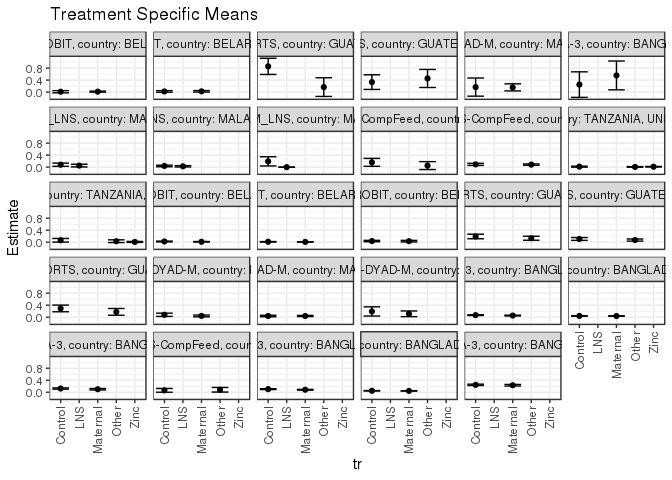

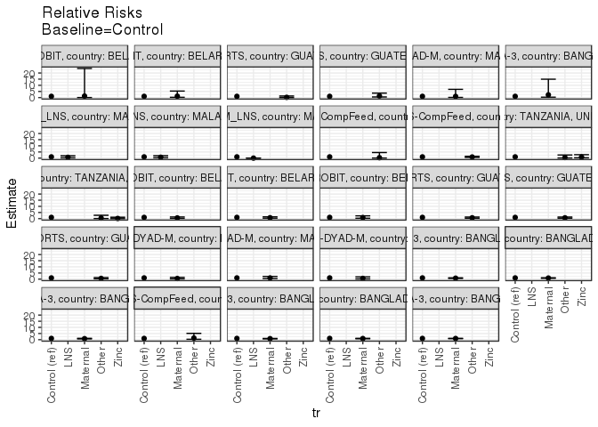

[figure not shown]

[figure not shown]

## Results Table

### Parameter: TSM

| agecat | studyid | country | intXgagebrth | intervention_level | baseline_level | estimate | ci_lower | ci_upper |
| --- | --- | --- | --- | --- | --- | --- | --- | --- |
| Birth | ki1000304b-SAS-CompFeed | INDIA | Preterm_Birth | Control | NA | 0.0634921 | 0.0012314 | 0.1257527 |
| Birth | ki1000304b-SAS-CompFeed | INDIA | Preterm_Birth | Other | NA | 0.0833333 | 0.0063666 | 0.1603001 |
| Birth | kiGH5241-JiVitA-3 | BANGLADESH | Full or late term_Birth | Control | NA | 0.0493854 | 0.0426381 | 0.0561328 |
| Birth | kiGH5241-JiVitA-3 | BANGLADESH | Full or late term_Birth | Maternal | NA | 0.0449258 | 0.0383691 | 0.0514825 |
| Birth | kiGH5241-JiVitA-3 | BANGLADESH | Preterm_Birth | Control | NA | 0.2461916 | 0.2238874 | 0.2684959 |
| Birth | kiGH5241-JiVitA-3 | BANGLADESH | Preterm_Birth | Maternal | NA | 0.2328925 | 0.2061859 | 0.2595990 |
| Birth | kiGH5241-JiVitA-3 | BANGLADESH | Early term_Birth | Control | NA | 0.1034082 | 0.0896286 | 0.1171878 |
| Birth | kiGH5241-JiVitA-3 | BANGLADESH | Early term_Birth | Maternal | NA | 0.0835962 | 0.0707265 | 0.0964659 |
| 6 months | iLiNS_DYADM_LNS | MALAWI | Full or late term_6 months | Control | NA | 0.0398230 | 0.0143002 | 0.0653458 |
| 6 months | iLiNS_DYADM_LNS | MALAWI | Full or late term_6 months | LNS | NA | 0.0277778 | 0.0058374 | 0.0497182 |
| 6 months | iLiNS_DYADM_LNS | MALAWI | Preterm_6 months | Control | NA | 0.1923077 | 0.0391063 | 0.3455091 |
| 6 months | iLiNS_DYADM_LNS | MALAWI | Preterm_6 months | LNS | NA | 0.0000000 | 0.0000000 | 0.0000000 |
| 6 months | iLiNS_DYADM_LNS | MALAWI | Early term_6 months | Control | NA | 0.0808081 | 0.0269846 | 0.1346316 |
| 6 months | iLiNS_DYADM_LNS | MALAWI | Early term_6 months | LNS | NA | 0.0515464 | 0.0074320 | 0.0956608 |
| 6 months | ki1000304b-SAS-CompFeed | INDIA | Preterm_6 months | Control | NA | 0.0926641 | 0.0580575 | 0.1272707 |
| 6 months | ki1000304b-SAS-CompFeed | INDIA | Preterm_6 months | Other | NA | 0.0844595 | 0.0614792 | 0.1074397 |
| 6 months | ki1000304b-SAS-CompFeed | INDIA | Early term_6 months | Control | NA | 0.1600000 | 0.0284659 | 0.2915341 |
| 6 months | ki1000304b-SAS-CompFeed | INDIA | Early term_6 months | Other | NA | 0.0526316 | -0.0789588 | 0.1842220 |
| 6 months | ki1066203-TanzaniaChild2 | TANZANIA, UNITED REPUBLIC OF | Full or late term_6 months | Control | NA | 0.0169492 | 0.0004723 | 0.0334260 |
| 6 months | ki1066203-TanzaniaChild2 | TANZANIA, UNITED REPUBLIC OF | Full or late term_6 months | Other | NA | 0.0079365 | -0.0030245 | 0.0188975 |
| 6 months | ki1066203-TanzaniaChild2 | TANZANIA, UNITED REPUBLIC OF | Full or late term_6 months | Zinc | NA | 0.0139442 | 0.0036815 | 0.0242070 |
| 6 months | ki1066203-TanzaniaChild2 | TANZANIA, UNITED REPUBLIC OF | Preterm_6 months | Control | NA | 0.0634921 | 0.0031559 | 0.1238282 |
| 6 months | ki1066203-TanzaniaChild2 | TANZANIA, UNITED REPUBLIC OF | Preterm_6 months | Other | NA | 0.0327869 | -0.0119926 | 0.0775663 |
| 6 months | ki1066203-TanzaniaChild2 | TANZANIA, UNITED REPUBLIC OF | Preterm_6 months | Zinc | NA | 0.0081967 | -0.0078352 | 0.0242286 |
| 6 months | ki1119695-PROBIT | BELARUS | Full or late term_6 months | Control | NA | 0.0134731 | 0.0059732 | 0.0209730 |
| 6 months | ki1119695-PROBIT | BELARUS | Full or late term_6 months | Maternal | NA | 0.0098668 | 0.0058720 | 0.0138616 |
| 6 months | ki1119695-PROBIT | BELARUS | Preterm_6 months | Control | NA | 0.0382775 | 0.0161886 | 0.0603664 |
| 6 months | ki1119695-PROBIT | BELARUS | Preterm_6 months | Maternal | NA | 0.0335570 | 0.0080534 | 0.0590607 |
| 6 months | ki1119695-PROBIT | BELARUS | Early term_6 months | Control | NA | 0.0238563 | 0.0108441 | 0.0368685 |
| 6 months | ki1119695-PROBIT | BELARUS | Early term_6 months | Maternal | NA | 0.0138340 | 0.0050303 | 0.0226377 |
| 6 months | ki1135781-COHORTS | GUATEMALA | Full or late term_6 months | Control | NA | 0.1065089 | 0.0599379 | 0.1530798 |
| 6 months | ki1135781-COHORTS | GUATEMALA | Full or late term_6 months | Other | NA | 0.0710900 | 0.0363708 | 0.1058093 |
| 6 months | ki1135781-COHORTS | GUATEMALA | Preterm_6 months | Control | NA | 0.2923077 | 0.1812326 | 0.4033828 |
| 6 months | ki1135781-COHORTS | GUATEMALA | Preterm_6 months | Other | NA | 0.1777778 | 0.0655609 | 0.2899947 |
| 6 months | ki1135781-COHORTS | GUATEMALA | Early term_6 months | Control | NA | 0.1904762 | 0.1151830 | 0.2657694 |
| 6 months | ki1135781-COHORTS | GUATEMALA | Early term_6 months | Other | NA | 0.1313131 | 0.0646197 | 0.1980066 |
| 6 months | ki1148112-iLiNS-DYAD-M | MALAWI | Full or late term_6 months | Control | NA | 0.0398230 | 0.0143102 | 0.0653358 |
| 6 months | ki1148112-iLiNS-DYAD-M | MALAWI | Full or late term_6 months | Maternal | NA | 0.0400000 | 0.0218812 | 0.0581188 |
| 6 months | ki1148112-iLiNS-DYAD-M | MALAWI | Preterm_6 months | Control | NA | 0.1923077 | 0.0397243 | 0.3448911 |
| 6 months | ki1148112-iLiNS-DYAD-M | MALAWI | Preterm_6 months | Maternal | NA | 0.1136364 | 0.0191844 | 0.2080883 |
| 6 months | ki1148112-iLiNS-DYAD-M | MALAWI | Early term_6 months | Control | NA | 0.0808081 | 0.0270270 | 0.1345892 |
| 6 months | ki1148112-iLiNS-DYAD-M | MALAWI | Early term_6 months | Maternal | NA | 0.0434783 | 0.0139600 | 0.0729966 |
| 6 months | kiGH5241-JiVitA-3 | BANGLADESH | Full or late term_6 months | Control | NA | 0.0432873 | 0.0356577 | 0.0509169 |
| 6 months | kiGH5241-JiVitA-3 | BANGLADESH | Full or late term_6 months | Maternal | NA | 0.0387665 | 0.0321875 | 0.0453456 |
| 6 months | kiGH5241-JiVitA-3 | BANGLADESH | Preterm_6 months | Control | NA | 0.1245580 | 0.1037162 | 0.1453997 |
| 6 months | kiGH5241-JiVitA-3 | BANGLADESH | Preterm_6 months | Maternal | NA | 0.1010236 | 0.0771009 | 0.1249463 |
| 6 months | kiGH5241-JiVitA-3 | BANGLADESH | Early term_6 months | Control | NA | 0.0689655 | 0.0566597 | 0.0812713 |
| 6 months | kiGH5241-JiVitA-3 | BANGLADESH | Early term_6 months | Maternal | NA | 0.0544612 | 0.0417242 | 0.0671982 |
| 24 months | ki1119695-PROBIT | BELARUS | Full or late term_24 months | Control | NA | 0.0227273 | -0.0042380 | 0.0496926 |
| 24 months | ki1119695-PROBIT | BELARUS | Full or late term_24 months | Maternal | NA | 0.0260223 | 0.0005421 | 0.0515025 |
| 24 months | ki1119695-PROBIT | BELARUS | Early term_24 months | Control | NA | 0.0131579 | -0.0232782 | 0.0495940 |
| 24 months | ki1119695-PROBIT | BELARUS | Early term_24 months | Maternal | NA | 0.0162162 | -0.0017696 | 0.0342021 |
| 24 months | ki1135781-COHORTS | GUATEMALA | Full or late term_24 months | Control | NA | 0.3333333 | 0.0900497 | 0.5766170 |
| 24 months | ki1135781-COHORTS | GUATEMALA | Full or late term_24 months | Other | NA | 0.4545455 | 0.1544659 | 0.7546250 |
| 24 months | ki1135781-COHORTS | GUATEMALA | Early term_24 months | Control | NA | 0.8571429 | 0.5873331 | 1.1269527 |
| 24 months | ki1135781-COHORTS | GUATEMALA | Early term_24 months | Other | NA | 0.1666667 | -0.1437087 | 0.4770421 |
| 24 months | ki1148112-iLiNS-DYAD-M | MALAWI | Full or late term_24 months | Control | NA | 0.1666667 | -0.1349799 | 0.4683132 |
| 24 months | ki1148112-iLiNS-DYAD-M | MALAWI | Full or late term_24 months | Maternal | NA | 0.1578947 | 0.0406170 | 0.2751724 |
| 24 months | kiGH5241-JiVitA-3 | BANGLADESH | Preterm_24 months | Control | NA | 0.2500000 | -0.1750807 | 0.6750807 |
| 24 months | kiGH5241-JiVitA-3 | BANGLADESH | Preterm_24 months | Maternal | NA | 0.5555556 | 0.0767361 | 1.0343750 |

### Parameter: E(Y)

| agecat | studyid | country | intXgagebrth | intervention_level | baseline_level | estimate | ci_lower | ci_upper |
| --- | --- | --- | --- | --- | --- | --- | --- | --- |
| Birth | ki1000304b-SAS-CompFeed | INDIA | Preterm_Birth | NA | NA | 0.0740741 | 0.0238558 | 0.1242923 |
| Birth | kiGH5241-JiVitA-3 | BANGLADESH | Full or late term_Birth | NA | NA | 0.0470551 | 0.0423544 | 0.0517558 |
| Birth | kiGH5241-JiVitA-3 | BANGLADESH | Preterm_Birth | NA | NA | 0.2400636 | 0.2228442 | 0.2572830 |
| Birth | kiGH5241-JiVitA-3 | BANGLADESH | Early term_Birth | NA | NA | 0.0935912 | 0.0841293 | 0.1030532 |
| 6 months | iLiNS_DYADM_LNS | MALAWI | Full or late term_6 months | NA | NA | 0.0339367 | 0.0170375 | 0.0508358 |
| 6 months | iLiNS_DYADM_LNS | MALAWI | Preterm_6 months | NA | NA | 0.1111111 | 0.0182521 | 0.2039702 |
| 6 months | iLiNS_DYADM_LNS | MALAWI | Early term_6 months | NA | NA | 0.0663265 | 0.0313987 | 0.1012544 |
| 6 months | ki1000304b-SAS-CompFeed | INDIA | Preterm_6 months | NA | NA | 0.0882883 | 0.0679925 | 0.1085841 |
| 6 months | ki1000304b-SAS-CompFeed | INDIA | Early term_6 months | NA | NA | 0.1136364 | 0.0167258 | 0.2105470 |
| 6 months | ki1066203-TanzaniaChild2 | TANZANIA, UNITED REPUBLIC OF | Full or late term_6 months | NA | NA | 0.0131313 | 0.0060366 | 0.0202260 |
| 6 months | ki1066203-TanzaniaChild2 | TANZANIA, UNITED REPUBLIC OF | Preterm_6 months | NA | NA | 0.0284553 | 0.0076354 | 0.0492751 |
| 6 months | ki1119695-PROBIT | BELARUS | Full or late term_6 months | NA | NA | 0.0114958 | 0.0072157 | 0.0157759 |
| 6 months | ki1119695-PROBIT | BELARUS | Preterm_6 months | NA | NA | 0.0355030 | 0.0180273 | 0.0529787 |
| 6 months | ki1119695-PROBIT | BELARUS | Early term_6 months | NA | NA | 0.0192453 | 0.0107772 | 0.0277135 |
| 6 months | ki1135781-COHORTS | GUATEMALA | Full or late term_6 months | NA | NA | 0.0868421 | 0.0584912 | 0.1151930 |
| 6 months | ki1135781-COHORTS | GUATEMALA | Preterm_6 months | NA | NA | 0.2454545 | 0.1646635 | 0.3262456 |
| 6 months | ki1135781-COHORTS | GUATEMALA | Early term_6 months | NA | NA | 0.1617647 | 0.1111094 | 0.2124200 |
| 6 months | ki1148112-iLiNS-DYAD-M | MALAWI | Full or late term_6 months | NA | NA | 0.0399408 | 0.0251683 | 0.0547133 |
| 6 months | ki1148112-iLiNS-DYAD-M | MALAWI | Preterm_6 months | NA | NA | 0.1428571 | 0.0602912 | 0.2254231 |
| 6 months | ki1148112-iLiNS-DYAD-M | MALAWI | Early term_6 months | NA | NA | 0.0565371 | 0.0295813 | 0.0834929 |
| 6 months | kiGH5241-JiVitA-3 | BANGLADESH | Full or late term_6 months | NA | NA | 0.0409525 | 0.0359344 | 0.0459707 |
| 6 months | kiGH5241-JiVitA-3 | BANGLADESH | Preterm_6 months | NA | NA | 0.1135225 | 0.0977257 | 0.1293194 |
| 6 months | kiGH5241-JiVitA-3 | BANGLADESH | Early term_6 months | NA | NA | 0.0617426 | 0.0528780 | 0.0706073 |
| 24 months | ki1119695-PROBIT | BELARUS | Full or late term_24 months | NA | NA | 0.0249377 | 0.0055706 | 0.0443047 |
| 24 months | ki1119695-PROBIT | BELARUS | Early term_24 months | NA | NA | 0.0145278 | -0.0071985 | 0.0362542 |
| 24 months | ki1135781-COHORTS | GUATEMALA | Full or late term_24 months | NA | NA | 0.3846154 | 0.1939092 | 0.5753215 |
| 24 months | ki1135781-COHORTS | GUATEMALA | Early term_24 months | NA | NA | 0.5384615 | 0.2564033 | 0.8205198 |
| 24 months | ki1148112-iLiNS-DYAD-M | MALAWI | Full or late term_24 months | NA | NA | 0.1590909 | 0.0497680 | 0.2684138 |
| 24 months | kiGH5241-JiVitA-3 | BANGLADESH | Preterm_24 months | NA | NA | 0.4117647 | 0.0674341 | 0.7560953 |

### Parameter: RR

| agecat | studyid | country | intXgagebrth | intervention_level | baseline_level | estimate | ci_lower | ci_upper |
| --- | --- | --- | --- | --- | --- | --- | --- | --- |
| Birth | ki1000304b-SAS-CompFeed | INDIA | Preterm_Birth | Control | Control | 1.0000000 | 1.0000000 | 1.0000000 |
| Birth | ki1000304b-SAS-CompFeed | INDIA | Preterm_Birth | Other | Control | 1.3125000 | 0.3353475 | 5.1369284 |
| Birth | kiGH5241-JiVitA-3 | BANGLADESH | Full or late term_Birth | Control | Control | 1.0000000 | 1.0000000 | 1.0000000 |
| Birth | kiGH5241-JiVitA-3 | BANGLADESH | Full or late term_Birth | Maternal | Control | 0.9096974 | 0.7449281 | 1.1109117 |
| Birth | kiGH5241-JiVitA-3 | BANGLADESH | Preterm_Birth | Control | Control | 1.0000000 | 1.0000000 | 1.0000000 |
| Birth | kiGH5241-JiVitA-3 | BANGLADESH | Preterm_Birth | Maternal | Control | 0.9459804 | 0.8173400 | 1.0948673 |
| Birth | kiGH5241-JiVitA-3 | BANGLADESH | Early term_Birth | Control | Control | 1.0000000 | 1.0000000 | 1.0000000 |
| Birth | kiGH5241-JiVitA-3 | BANGLADESH | Early term_Birth | Maternal | Control | 0.8084098 | 0.6594853 | 0.9909644 |
| 6 months | iLiNS_DYADM_LNS | MALAWI | Full or late term_6 months | Control | Control | 1.0000000 | 1.0000000 | 1.0000000 |
| 6 months | iLiNS_DYADM_LNS | MALAWI | Full or late term_6 months | LNS | Control | 0.6975309 | 0.2522395 | 1.9289183 |
| 6 months | iLiNS_DYADM_LNS | MALAWI | Preterm_6 months | Control | Control | 1.0000000 | 1.0000000 | 1.0000000 |
| 6 months | iLiNS_DYADM_LNS | MALAWI | Preterm_6 months | LNS | Control | 0.0000000 | 0.0000000 | 0.0000000 |
| 6 months | iLiNS_DYADM_LNS | MALAWI | Early term_6 months | Control | Control | 1.0000000 | 1.0000000 | 1.0000000 |
| 6 months | iLiNS_DYADM_LNS | MALAWI | Early term_6 months | LNS | Control | 0.6378866 | 0.2156579 | 1.8867815 |
| 6 months | ki1000304b-SAS-CompFeed | INDIA | Preterm_6 months | Control | Control | 1.0000000 | 1.0000000 | 1.0000000 |
| 6 months | ki1000304b-SAS-CompFeed | INDIA | Preterm_6 months | Other | Control | 0.9114583 | 0.5744545 | 1.4461656 |
| 6 months | ki1000304b-SAS-CompFeed | INDIA | Early term_6 months | Control | Control | 1.0000000 | 1.0000000 | 1.0000000 |
| 6 months | ki1000304b-SAS-CompFeed | INDIA | Early term_6 months | Other | Control | 0.3289474 | 0.0238228 | 4.5421397 |
| 6 months | ki1066203-TanzaniaChild2 | TANZANIA, UNITED REPUBLIC OF | Full or late term_6 months | Control | Control | 1.0000000 | 1.0000000 | 1.0000000 |
| 6 months | ki1066203-TanzaniaChild2 | TANZANIA, UNITED REPUBLIC OF | Full or late term_6 months | Other | Control | 0.4682540 | 0.0864953 | 2.5349566 |
| 6 months | ki1066203-TanzaniaChild2 | TANZANIA, UNITED REPUBLIC OF | Full or late term_6 months | Zinc | Control | 0.8227092 | 0.2430562 | 2.7847479 |
| 6 months | ki1066203-TanzaniaChild2 | TANZANIA, UNITED REPUBLIC OF | Preterm_6 months | Control | Control | 1.0000000 | 1.0000000 | 1.0000000 |
| 6 months | ki1066203-TanzaniaChild2 | TANZANIA, UNITED REPUBLIC OF | Preterm_6 months | Other | Control | 0.5163934 | 0.0978092 | 2.7263504 |
| 6 months | ki1066203-TanzaniaChild2 | TANZANIA, UNITED REPUBLIC OF | Preterm_6 months | Zinc | Control | 0.1290984 | 0.0146735 | 1.1358142 |
| 6 months | ki1119695-PROBIT | BELARUS | Full or late term_6 months | Control | Control | 1.0000000 | 1.0000000 | 1.0000000 |
| 6 months | ki1119695-PROBIT | BELARUS | Full or late term_6 months | Maternal | Control | 0.7323357 | 0.3714768 | 1.4437390 |
| 6 months | ki1119695-PROBIT | BELARUS | Preterm_6 months | Control | Control | 1.0000000 | 1.0000000 | 1.0000000 |
| 6 months | ki1119695-PROBIT | BELARUS | Preterm_6 months | Maternal | Control | 0.8766779 | 0.3372085 | 2.2791954 |
| 6 months | ki1119695-PROBIT | BELARUS | Early term_6 months | Control | Control | 1.0000000 | 1.0000000 | 1.0000000 |
| 6 months | ki1119695-PROBIT | BELARUS | Early term_6 months | Maternal | Control | 0.5798884 | 0.2495025 | 1.3477644 |
| 6 months | ki1135781-COHORTS | GUATEMALA | Full or late term_6 months | Control | Control | 1.0000000 | 1.0000000 | 1.0000000 |
| 6 months | ki1135781-COHORTS | GUATEMALA | Full or late term_6 months | Other | Control | 0.6674566 | 0.3465249 | 1.2856168 |
| 6 months | ki1135781-COHORTS | GUATEMALA | Preterm_6 months | Control | Control | 1.0000000 | 1.0000000 | 1.0000000 |
| 6 months | ki1135781-COHORTS | GUATEMALA | Preterm_6 months | Other | Control | 0.6081871 | 0.2911125 | 1.2706138 |
| 6 months | ki1135781-COHORTS | GUATEMALA | Early term_6 months | Control | Control | 1.0000000 | 1.0000000 | 1.0000000 |
| 6 months | ki1135781-COHORTS | GUATEMALA | Early term_6 months | Other | Control | 0.6893939 | 0.3622084 | 1.3121288 |
| 6 months | ki1148112-iLiNS-DYAD-M | MALAWI | Full or late term_6 months | Control | Control | 1.0000000 | 1.0000000 | 1.0000000 |
| 6 months | ki1148112-iLiNS-DYAD-M | MALAWI | Full or late term_6 months | Maternal | Control | 1.0044444 | 0.4583236 | 2.2013018 |
| 6 months | ki1148112-iLiNS-DYAD-M | MALAWI | Preterm_6 months | Control | Control | 1.0000000 | 1.0000000 | 1.0000000 |
| 6 months | ki1148112-iLiNS-DYAD-M | MALAWI | Preterm_6 months | Maternal | Control | 0.5909091 | 0.1872752 | 1.8644946 |
| 6 months | ki1148112-iLiNS-DYAD-M | MALAWI | Early term_6 months | Control | Control | 1.0000000 | 1.0000000 | 1.0000000 |
| 6 months | ki1148112-iLiNS-DYAD-M | MALAWI | Early term_6 months | Maternal | Control | 0.5380435 | 0.2079326 | 1.3922336 |
| 6 months | kiGH5241-JiVitA-3 | BANGLADESH | Full or late term_6 months | Control | Control | 1.0000000 | 1.0000000 | 1.0000000 |
| 6 months | kiGH5241-JiVitA-3 | BANGLADESH | Full or late term_6 months | Maternal | Control | 0.8955628 | 0.7011766 | 1.1438384 |
| 6 months | kiGH5241-JiVitA-3 | BANGLADESH | Preterm_6 months | Control | Control | 1.0000000 | 1.0000000 | 1.0000000 |
| 6 months | kiGH5241-JiVitA-3 | BANGLADESH | Preterm_6 months | Maternal | Control | 0.8110569 | 0.6069139 | 1.0838658 |
| 6 months | kiGH5241-JiVitA-3 | BANGLADESH | Early term_6 months | Control | Control | 1.0000000 | 1.0000000 | 1.0000000 |
| 6 months | kiGH5241-JiVitA-3 | BANGLADESH | Early term_6 months | Maternal | Control | 0.7896871 | 0.5884365 | 1.0597674 |
| 24 months | ki1119695-PROBIT | BELARUS | Full or late term_24 months | Control | Control | 1.0000000 | 1.0000000 | 1.0000000 |
| 24 months | ki1119695-PROBIT | BELARUS | Full or late term_24 months | Maternal | Control | 1.1449814 | 0.2468434 | 5.3109875 |
| 24 months | ki1119695-PROBIT | BELARUS | Early term_24 months | Control | Control | 1.0000000 | 1.0000000 | 1.0000000 |
| 24 months | ki1119695-PROBIT | BELARUS | Early term_24 months | Maternal | Control | 1.2324324 | 0.0640686 | 23.7072278 |
| 24 months | ki1135781-COHORTS | GUATEMALA | Full or late term_24 months | Control | Control | 1.0000000 | 1.0000000 | 1.0000000 |
| 24 months | ki1135781-COHORTS | GUATEMALA | Full or late term_24 months | Other | Control | 1.3636364 | 0.5096782 | 3.6483888 |
| 24 months | ki1135781-COHORTS | GUATEMALA | Early term_24 months | Control | Control | 1.0000000 | 1.0000000 | 1.0000000 |
| 24 months | ki1135781-COHORTS | GUATEMALA | Early term_24 months | Other | Control | 0.1944444 | 0.0294142 | 1.2853869 |
| 24 months | ki1148112-iLiNS-DYAD-M | MALAWI | Full or late term_24 months | Control | Control | 1.0000000 | 1.0000000 | 1.0000000 |
| 24 months | ki1148112-iLiNS-DYAD-M | MALAWI | Full or late term_24 months | Maternal | Control | 0.9473684 | 0.1339311 | 6.7012561 |
| 24 months | kiGH5241-JiVitA-3 | BANGLADESH | Preterm_24 months | Control | Control | 1.0000000 | 1.0000000 | 1.0000000 |
| 24 months | kiGH5241-JiVitA-3 | BANGLADESH | Preterm_24 months | Maternal | Control | 2.2222222 | 0.3302920 | 14.9512319 |

### Parameter: PAR

| agecat | studyid | country | intXgagebrth | intervention_level | baseline_level | estimate | ci_lower | ci_upper |
| --- | --- | --- | --- | --- | --- | --- | --- | --- |
| Birth | ki1000304b-SAS-CompFeed | INDIA | Preterm_Birth | Control | NA | 0.0105820 | -0.0449924 | 0.0661564 |
| Birth | kiGH5241-JiVitA-3 | BANGLADESH | Full or late term_Birth | Control | NA | -0.0023303 | -0.0072489 | 0.0025883 |
| Birth | kiGH5241-JiVitA-3 | BANGLADESH | Preterm_Birth | Control | NA | -0.0061281 | -0.0221580 | 0.0099019 |
| Birth | kiGH5241-JiVitA-3 | BANGLADESH | Early term_Birth | Control | NA | -0.0098170 | -0.0191911 | -0.0004428 |
| 6 months | iLiNS_DYADM_LNS | MALAWI | Full or late term_6 months | Control | NA | -0.0058864 | -0.0223437 | 0.0105710 |
| 6 months | iLiNS_DYADM_LNS | MALAWI | Preterm_6 months | Control | NA | -0.0811966 | -0.1517077 | -0.0106855 |
| 6 months | iLiNS_DYADM_LNS | MALAWI | Early term_6 months | Control | NA | -0.0144816 | -0.0489836 | 0.0200205 |
| 6 months | ki1000304b-SAS-CompFeed | INDIA | Preterm_6 months | Control | NA | -0.0043758 | -0.0268522 | 0.0181006 |
| 6 months | ki1000304b-SAS-CompFeed | INDIA | Early term_6 months | Control | NA | -0.0463636 | -0.1374022 | 0.0446749 |
| 6 months | ki1066203-TanzaniaChild2 | TANZANIA, UNITED REPUBLIC OF | Full or late term_6 months | Control | NA | -0.0038178 | -0.0176881 | 0.0100524 |
| 6 months | ki1066203-TanzaniaChild2 | TANZANIA, UNITED REPUBLIC OF | Preterm_6 months | Control | NA | -0.0350368 | -0.0820399 | 0.0119664 |
| 6 months | ki1119695-PROBIT | BELARUS | Full or late term_6 months | Control | NA | -0.0019772 | -0.0066143 | 0.0026598 |
| 6 months | ki1119695-PROBIT | BELARUS | Preterm_6 months | Control | NA | -0.0027746 | -0.0227559 | 0.0172068 |
| 6 months | ki1119695-PROBIT | BELARUS | Early term_6 months | Control | NA | -0.0046110 | -0.0117676 | 0.0025457 |
| 6 months | ki1135781-COHORTS | GUATEMALA | Full or late term_6 months | Control | NA | -0.0196668 | -0.0519698 | 0.0126363 |
| 6 months | ki1135781-COHORTS | GUATEMALA | Preterm_6 months | Control | NA | -0.0468531 | -0.1123052 | 0.0185989 |
| 6 months | ki1135781-COHORTS | GUATEMALA | Early term_6 months | Control | NA | -0.0287115 | -0.0776933 | 0.0202704 |
| 6 months | ki1148112-iLiNS-DYAD-M | MALAWI | Full or late term_6 months | Control | NA | 0.0001178 | -0.0207127 | 0.0209483 |
| 6 months | ki1148112-iLiNS-DYAD-M | MALAWI | Preterm_6 months | Control | NA | -0.0494505 | -0.1626047 | 0.0637036 |
| 6 months | ki1148112-iLiNS-DYAD-M | MALAWI | Early term_6 months | Control | NA | -0.0242710 | -0.0642129 | 0.0156710 |
| 6 months | kiGH5241-JiVitA-3 | BANGLADESH | Full or late term_6 months | Control | NA | -0.0023348 | -0.0075442 | 0.0028746 |
| 6 months | kiGH5241-JiVitA-3 | BANGLADESH | Preterm_6 months | Control | NA | -0.0110354 | -0.0259405 | 0.0038697 |
| 6 months | kiGH5241-JiVitA-3 | BANGLADESH | Early term_6 months | Control | NA | -0.0072229 | -0.0160704 | 0.0016247 |
| 24 months | ki1119695-PROBIT | BELARUS | Full or late term_24 months | Control | NA | 0.0022104 | -0.0225819 | 0.0270026 |
| 24 months | ki1119695-PROBIT | BELARUS | Early term_24 months | Control | NA | 0.0013700 | -0.0167366 | 0.0194765 |
| 24 months | ki1135781-COHORTS | GUATEMALA | Full or late term_24 months | Control | NA | 0.0512821 | -0.1138335 | 0.2163976 |
| 24 months | ki1135781-COHORTS | GUATEMALA | Early term_24 months | Control | NA | -0.3186813 | -0.5906318 | -0.0467309 |
| 24 months | ki1148112-iLiNS-DYAD-M | MALAWI | Full or late term_24 months | Control | NA | -0.0075758 | -0.2870869 | 0.2719354 |
| 24 months | kiGH5241-JiVitA-3 | BANGLADESH | Preterm_24 months | Control | NA | 0.1617647 | -0.1976690 | 0.5211984 |

### Parameter: PAF

| agecat | studyid | country | intXgagebrth | intervention_level | baseline_level | estimate | ci_lower | ci_upper |
| --- | --- | --- | --- | --- | --- | --- | --- | --- |
| Birth | ki1000304b-SAS-CompFeed | INDIA | Preterm_Birth | Control | NA | 0.1428571 | -0.9994682 | 0.6325554 |
| Birth | kiGH5241-JiVitA-3 | BANGLADESH | Full or late term_Birth | Control | NA | -0.0495228 | -0.1596534 | 0.0501489 |
| Birth | kiGH5241-JiVitA-3 | BANGLADESH | Preterm_Birth | Control | NA | -0.0255268 | -0.0947470 | 0.0393166 |
| Birth | kiGH5241-JiVitA-3 | BANGLADESH | Early term_Birth | Control | NA | -0.1048919 | -0.2095310 | -0.0093054 |
| 6 months | iLiNS_DYADM_LNS | MALAWI | Full or late term_6 months | Control | NA | -0.1734513 | -0.7632404 | 0.2190583 |
| 6 months | iLiNS_DYADM_LNS | MALAWI | Preterm_6 months | Control | NA | -0.7307692 | -1.2281095 | -0.3444412 |
| 6 months | iLiNS_DYADM_LNS | MALAWI | Early term_6 months | Control | NA | -0.2183372 | -0.8510206 | 0.1980934 |
| 6 months | ki1000304b-SAS-CompFeed | INDIA | Preterm_6 months | Control | NA | -0.0495627 | -0.3335124 | 0.1739246 |
| 6 months | ki1000304b-SAS-CompFeed | INDIA | Early term_6 months | Control | NA | -0.4080000 | -1.6309673 | 0.2464885 |
| 6 months | ki1066203-TanzaniaChild2 | TANZANIA, UNITED REPUBLIC OF | Full or late term_6 months | Control | NA | -0.2907432 | -1.9001985 | 0.4255504 |
| 6 months | ki1066203-TanzaniaChild2 | TANZANIA, UNITED REPUBLIC OF | Preterm_6 months | Control | NA | -1.2312925 | -3.2207911 | -0.1795576 |
| 6 months | ki1119695-PROBIT | BELARUS | Full or late term_6 months | Control | NA | -0.1719972 | -0.6227085 | 0.1535279 |
| 6 months | ki1119695-PROBIT | BELARUS | Preterm_6 months | Control | NA | -0.0781499 | -0.8393452 | 0.3680320 |
| 6 months | ki1119695-PROBIT | BELARUS | Early term_6 months | Control | NA | -0.2395884 | -0.6380730 | 0.0619591 |
| 6 months | ki1135781-COHORTS | GUATEMALA | Full or late term_6 months | Control | NA | -0.2264658 | -0.6533409 | 0.0901946 |
| 6 months | ki1135781-COHORTS | GUATEMALA | Preterm_6 months | Control | NA | -0.1908832 | -0.4876624 | 0.0466904 |
| 6 months | ki1135781-COHORTS | GUATEMALA | Early term_6 months | Control | NA | -0.1774892 | -0.5191712 | 0.0873440 |
| 6 months | ki1148112-iLiNS-DYAD-M | MALAWI | Full or late term_6 months | Control | NA | 0.0029499 | -0.6822329 | 0.4090539 |
| 6 months | ki1148112-iLiNS-DYAD-M | MALAWI | Preterm_6 months | Control | NA | -0.3461538 | -1.3993872 | 0.2447529 |
| 6 months | ki1148112-iLiNS-DYAD-M | MALAWI | Early term_6 months | Control | NA | -0.4292929 | -1.3024208 | 0.1127260 |
| 6 months | kiGH5241-JiVitA-3 | BANGLADESH | Full or late term_6 months | Control | NA | -0.0570124 | -0.1915169 | 0.0623085 |
| 6 months | kiGH5241-JiVitA-3 | BANGLADESH | Preterm_6 months | Control | NA | -0.0972091 | -0.2386662 | 0.0280935 |
| 6 months | kiGH5241-JiVitA-3 | BANGLADESH | Early term_6 months | Control | NA | -0.1169836 | -0.2716503 | 0.0188716 |
| 24 months | ki1119695-PROBIT | BELARUS | Full or late term_24 months | Control | NA | 0.0886364 | -1.6640669 | 0.6882272 |
| 24 months | ki1119695-PROBIT | BELARUS | Early term_24 months | Control | NA | 0.0942982 | -2.9987503 | 0.7948620 |
| 24 months | ki1135781-COHORTS | GUATEMALA | Full or late term_24 months | Control | NA | 0.1333333 | -0.4229543 | 0.4721467 |
| 24 months | ki1135781-COHORTS | GUATEMALA | Early term_24 months | Control | NA | -0.5918367 | -1.4995868 | -0.0137452 |
| 24 months | ki1148112-iLiNS-DYAD-M | MALAWI | Full or late term_24 months | Control | NA | -0.0476190 | -4.6036123 | 0.8041432 |
| 24 months | kiGH5241-JiVitA-3 | BANGLADESH | Preterm_24 months | Control | NA | 0.3928571 | -1.4430474 | 0.8491137 |